# Time series analysis and forecast: Stock prices forecasting

Francisco Esteves Muñoz

2023-04-22

# 1 Introduction

The aim of this final project, is to apply advanced methods for time series forecast to stock market prices. Stock prices are one of the principal assets to invest nowadays, and trying to understand the behavior of the stock prices is key to make a wise investment. Although there are many technical insights which tries to detect upwards and downwards trends, those methods are not proven to work well for medium-term. We will apply many different algorithms and techniques to understand if this complex problem can be addressed with a structured way.

We will try to predict stock prices in a *1 month* horizon. This is larger than the typical values adopted for technical analysis, but is a better horizon to make short term investment without falling into the day trading strategies.

# 2 Data preprocessing and visualization tools

## 2.1 Data loading

This project will consider the 10 biggest companies being traded in the US stock market, mainly in New York Stock Exchange and Nasdaq. The information has been extracted from [1], API for obtaining end of day stock prices. Stock prices are adjusted by splits and dividends in this calculations.

The 10 biggest market capitalization companies in the S&P500 (September 2022), are:

```r
# Select the 10 biggest companies in the S&P 500:
tickers <- c('AAPL',
             'MSFT',
             'GOOGL',
             'PG',
             'AMZN',
             'TSLA',
             'BRK-B',
             'JNJ',
             'JPM',
             'V')
```

Then, we can download the data from the API and store it into a list of data frames.

```r
# Initialize an empty list to store the closing prices
closing_prices <- list()

time_series_list <- list()

# Loop over each ticker in the list
for (ticker in tickers) {

  endpoint <- "https://eodhistoricaldata.com/api/eod/"

  # Set the parameters for the API request
  params <- list(api_token = api_key,
                 symbol = ticker,
                 period = "d",
                 order = "d",
                 from = "2011-01-01",
                 to = "2023-03-01")

  # Construct the API query URL
  query_url <- paste0(endpoint, params$symbol, '.US?from=', params$from, '&to=', params$to, '&period=d&fmt=json&api_token=', api_key)

  # Send a GET request to the API endpoint and parse the response
  response <- GET(query_url)

  response_content <- content(response, "text", encoding = 'UTF-8')
  response_data <- fromJSON(response_content, flatten = TRUE)

  # Extract the closing price data from the response
  closing_prices <- response_data[, c("date", "adjusted_close")]

  time_series_list <- append(time_series_list, closing_prices)

}
```

After putting all together, we can print the first rows of the data. The data gathered is obtained since 2011 and has stock prices for every day in which the stock market has open (251 days per year aprox.).

```r
stock_prices <- data.frame(time_series_list$date,
                           time_series_list[2]$adjusted_close,
                           time_series_list[4]$adjusted_close,
                           time_series_list[6]$adjusted_close,
                           time_series_list[8]$adjusted_close,
                           time_series_list[10]$adjusted_close,
                           time_series_list[12]$adjusted_close,
                           time_series_list[14]$adjusted_close,
                           time_series_list[16]$adjusted_close,
                           time_series_list[18]$adjusted_close,
                           time_series_list[20]$adjusted_close)


# Change the column names
names(stock_prices) <- c("date", tickers)
# Remove the "-":
names(stock_prices)[8] <- 'BRK'
# Show the data frame
head(stock_prices)
```

```
##         date    AAPL    MSFT   GOOGL      PG   AMZN   TSLA   BRK     JNJ
## 1 2011-01-03 10.0181 21.8055 15.1234 44.9862 9.2110 1.7747 80.41 44.2044
## 2 2011-01-04 10.0704 21.8893 15.0676 45.1112 9.2505 1.7780 80.17 44.5774
## 3 2011-01-05 10.1528 21.8211 15.2415 45.0070 9.3710 1.7887 80.91 44.5492
## 4 2011-01-06 10.1445 22.4601 15.3523 44.9306 9.2930 1.8587 80.37 44.4788
## 5 2011-01-07 10.2172 22.2887 15.4259 44.7986 9.2745 1.8827 79.74 44.0496
## 6 2011-01-10 10.4097 21.9925 15.3701 44.7014 9.2340 1.8967 79.65 43.7400
##       JPM       V
## 1 31.1544 16.1534
## 2 31.6053 16.1718
## 3 31.9917 16.5131
## 4 31.8343 16.7604
## 5 31.2331 16.7123
## 6 31.0613 16.4489
```

## 2.2 Data Visualization

After storing the data into a data frame, we can turn it into a time series with frequency 251. Some prints are shown below for the time series. We can see that there is a high correlation:

- Present upwards trend
- Have almost the same cycles

```r
# Set the first column as date format:
stock_prices$date <- as.Date(stock_prices$date)

# Convert data frame to time series object
ts <- ts(stock_prices[, -1], start = c(year(min(stock_prices$date)),
                                      month(min(stock_prices$date)),
                                      day(min(stock_prices$date))),
        frequency = 251) # Assumes daily frequency

# Add row names to time series object
rownames(ts) <- stock_prices$date

# Print time series object
print(ts[1:10,])
```

```
##          AAPL    MSFT   GOOGL      PG   AMZN   TSLA   BRK     JNJ     JPM
## 14977 10.0181 21.8055 15.1234 44.9862 9.2110 1.7747 80.41 44.2044 31.1544
## 14978 10.0704 21.8893 15.0676 45.1112 9.2505 1.7780 80.17 44.5774 31.6053
## 14979 10.1528 21.8211 15.2415 45.0070 9.3710 1.7887 80.91 44.5492 31.9917
## 14980 10.1445 22.4601 15.3523 44.9306 9.2930 1.8587 80.37 44.4788 31.8343
## 14981 10.2172 22.2887 15.4259 44.7986 9.2745 1.8827 79.74 44.0496 31.2331
## 14984 10.4097 21.9925 15.3701 44.7014 9.2340 1.8967 79.65 43.7400 31.0613
## 14985 10.3850 21.9068 15.4152 44.4791 9.2170 1.7973 79.40 43.8174 31.2045
## 14986 10.4695 22.2497 15.4367 45.1251 9.2040 1.7973 80.74 43.9792 31.9989
## 14987 10.5078 21.9692 15.4322 45.4793 9.2765 1.7480 80.76 44.2677 31.8128
## 14988 10.5929 22.0549 15.6196 45.5140 9.4375 1.7167 81.65 44.0144 32.1420
##             V
## 14977 16.1534
## 14978 16.1718
## 14979 16.5131
## 14980 16.7604
## 14981 16.7123
## 14984 16.4489
## 14985 16.4650
## 14986 16.6322
## 14987 16.2954
## 14988 16.2909
```

Now we can print the time series to see the trends, cycles and seasonalities.

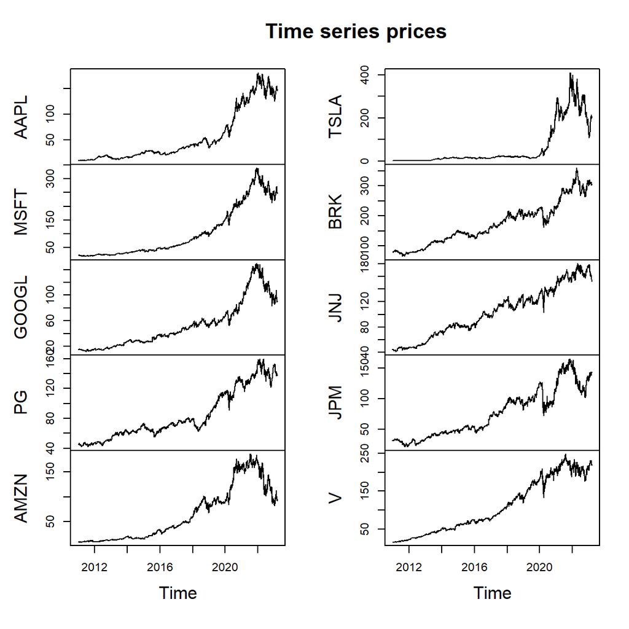

```r
plot(ts, main='Time series prices')
```

We can also compute a correlogram to find out correlations between stock prices the last year.

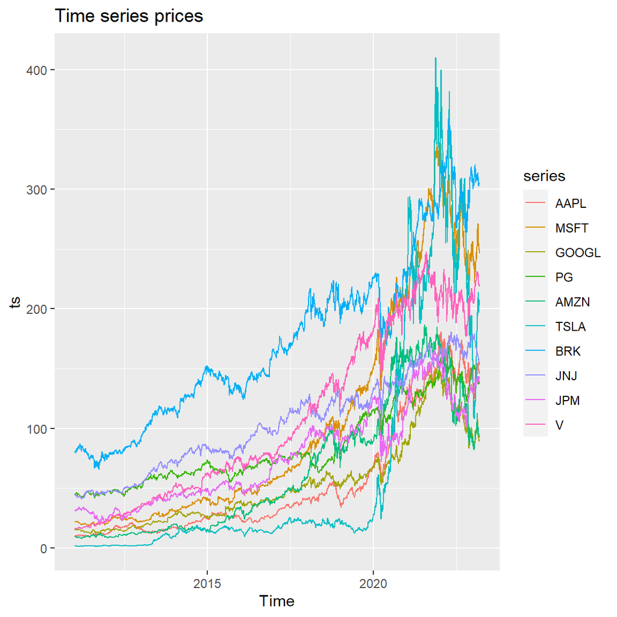

```r
autoplot(ts) + ggtitle("Time series prices")
```

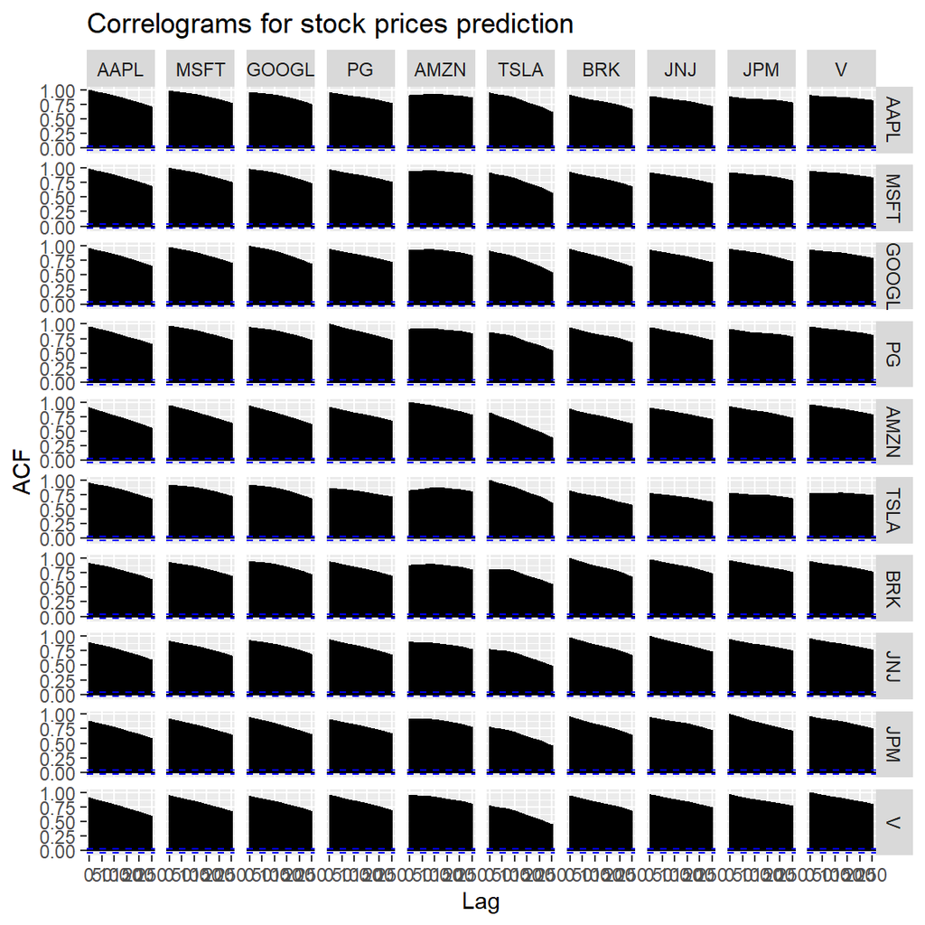

```r
ggAcf(ts, lag.max = 251) + ggtitle("Correlograms for stock prices prediction")
```

Other important thing to check, before starting our deep analysis, it to deduce if there is any seasonality. For every stock price, we can plot a seasonal plot, and also the mean over the year.

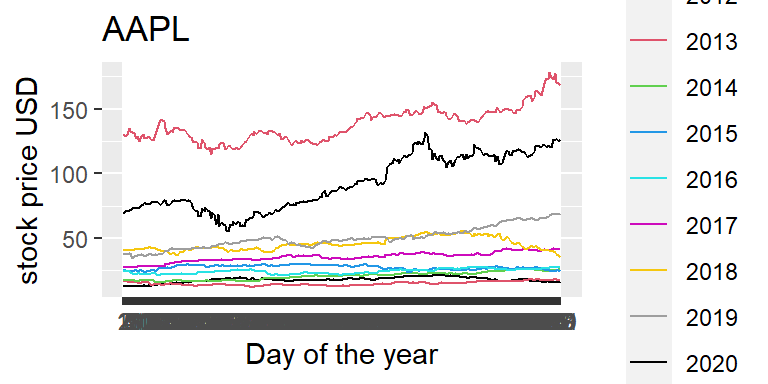

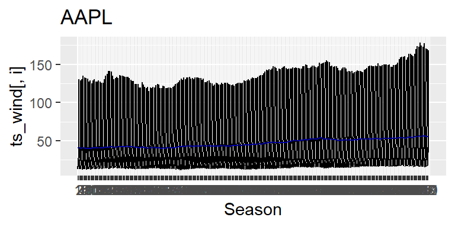

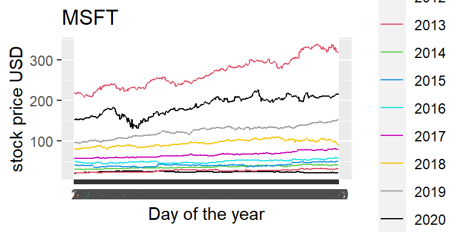

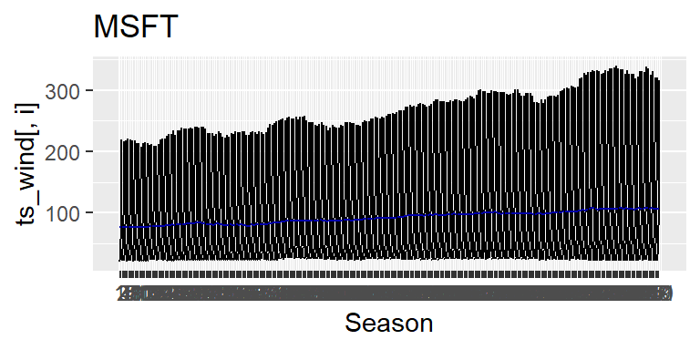

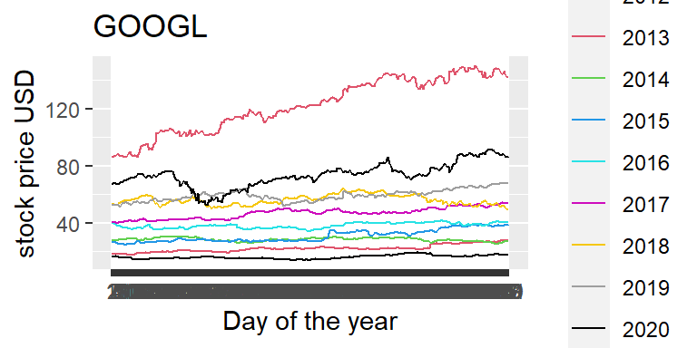

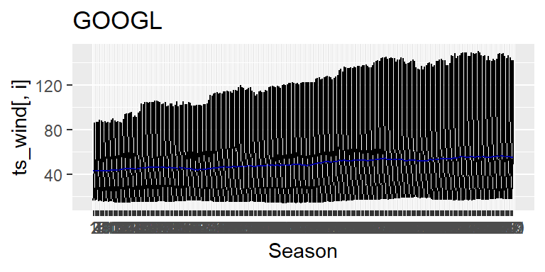

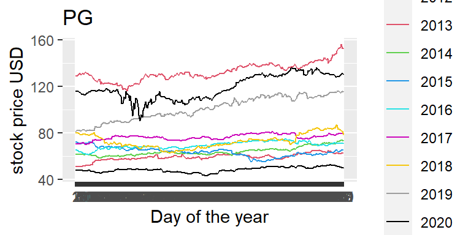

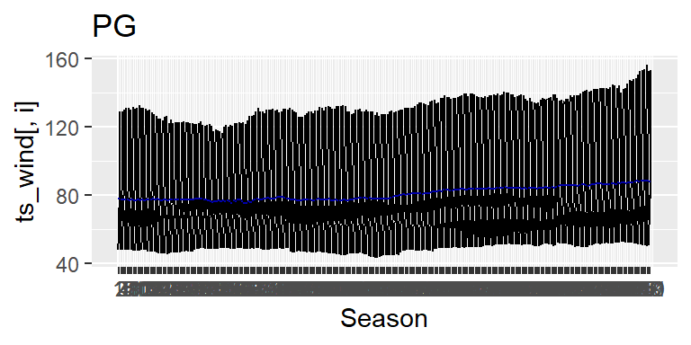

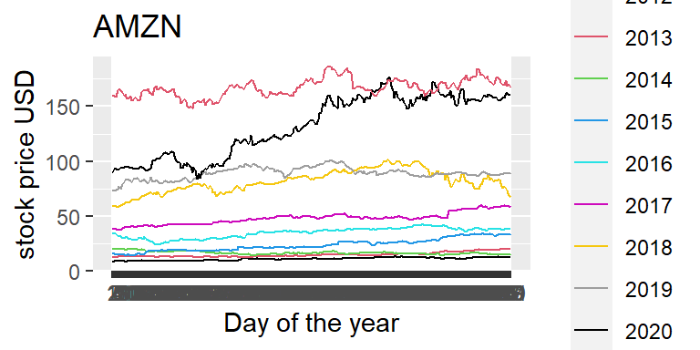

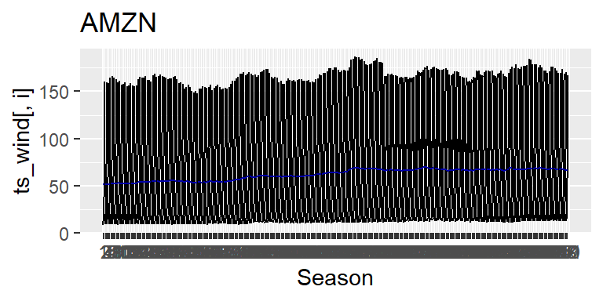

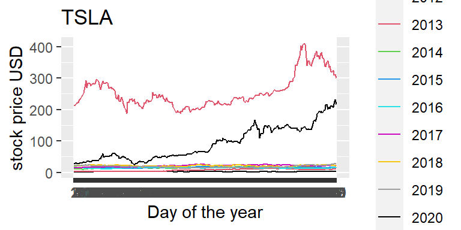

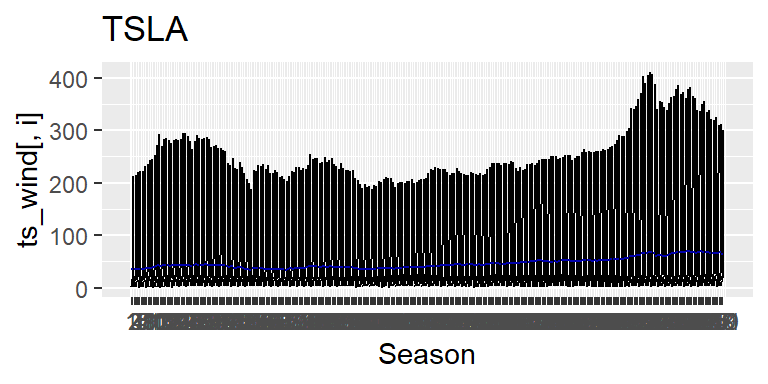

[8 more figures not shown]

```r
window_start <- c(2012,1)
window_end <- c(2021,251)

ts_wind <- window(ts, start = window_start, end = window_end)
for (i in 1:10){
  p <-  ggseasonplot(ts_wind[,i],
              ylab="stock price USD",
              xlab="Day of the year",
              main= tickers[i],
              col=1:10)
  print(p)

  q <-  ggsubseriesplot(ts_wind[,i])  + ggtitle(tickers[i])
  print(q)
}
```

Is it clear that no seasonality appears for any of the companies prices. Maybe, more volatility is seen at the end of the year for some companies like Apple (AAPL), Microsoft (MSFT), Procter & Gamble (PG).

# 3 Data transformation

We will transform the initial data set to make the data stationary:

$$y_j = (y_j-y_{j-1})/y_j$$

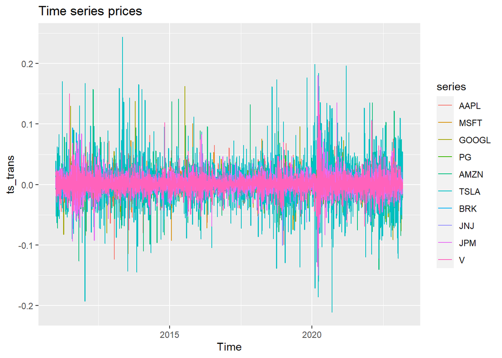

```r
# Define a custom function to apply to each row
transformation <- function(x) {
  result <- (diff(x) / x)[-1]
  return(result)
}

# Apply the function to each row using apply()
result <- apply(ts, 2, transformation)

# Convert the result back to a time series object
ts_trans <- ts(result, frequency = 251, start = c(2011, 1))
colnames(ts_trans) <- colnames(ts)

autoplot(ts_trans) + ggtitle("Time series prices")
```

We can appreciate that the resulting time series are stationary. Some high variance is observed by the year 2020, but we will consider still valid for this analysis.

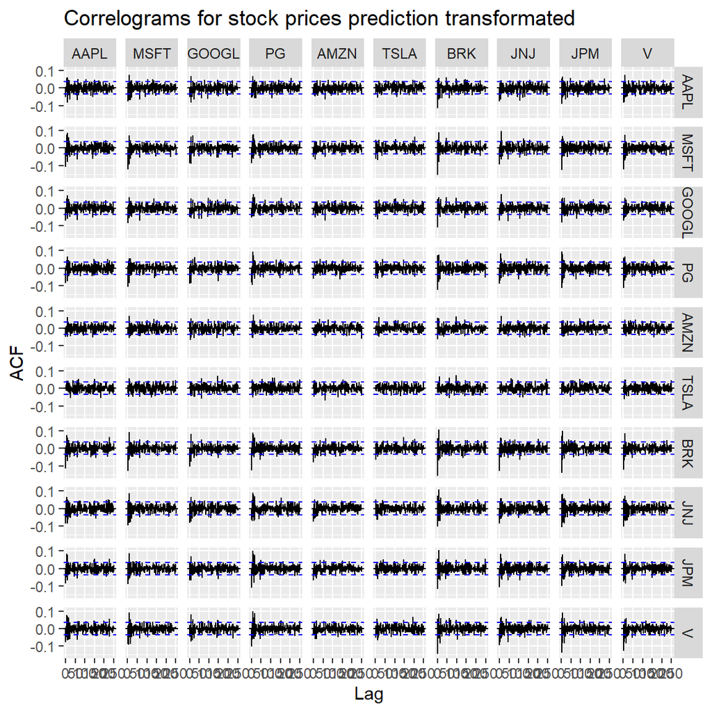

```r
ggAcf(ts_trans, lag.max = 251) + ggtitle("Correlograms for stock prices prediction transformated")
```

After transforming the data set, the variables seems uncorrelated, almost all the values are inside the confidence interval.

# 4 Vector Auto Regressive Model

For extracting the relations between those time series, we can use a vector auto regressive model, in which every variable affects the other. This section was constructed following code on [2].

```r
library(tsibble)
library(tidyverse) # great collection of packages to visualize and manage datasets
library(lubridate) # to work with dates
library(fpp3)
```

To work with the vars package, we have to transform the *time series* object into a *tsibble*.

```r
ts_tran_df <- as.data.frame(ts_trans)
```

One important thing to do, is to fill every NA value with the previous value. The stock market does not operate on weekends and holidays, so we can assume the price is constant for those periods.

```r
# Generate a data frame with dates and stock prices:
df1 <- cbind(stock_prices$date[-1],ts_tran_df)
names(df1)[1] <- 'date'

# Pass it to tsibble:
ts_tsibble <- as_tsibble(df1)
```

```
## Using `date` as index variable.
```

```r
# Make the NA values for the days missing:
ts_data_padded <- ts_tsibble %>% padr::pad()
```

```
## pad applied on the interval: day
```

```r
# Fill those NAs with previous vlaues:
ts_tsibble3 <- ts_data_padded %>% tidyr::fill(AAPL,MSFT,GOOGL,PG,AMZN,TSLA,BRK,JNJ,JPM,V) %>% as_tsibble()
```

```
## Using `date` as index variable.
```

Later, we can model the vector autoregressive. For doing that, we can perform the training with all the values before 2023, and then use January, February of 2023 as testing. We will perform three models, one that is the classical AR(1), with all the terms for the one lag autoregressive, and then other which minimize BIC and AIC.

```r
# Define the VAR model using the formula interface:
fit <-  ts_tsibble3 %>% filter(year(date)<2023) %>%
        fabletools::model(
             var_1 = fable::VAR(vars(AAPL,MSFT,GOOGL,PG,AMZN,TSLA,BRK,JNJ,JPM,V) ~ 0+AR(1)),
             aicc  = fable::VAR(vars(AAPL,MSFT,GOOGL,PG,AMZN,TSLA,BRK,JNJ,JPM,V), ic='aicc'),
             bic  = fable::VAR(vars(AAPL,MSFT,GOOGL,PG,AMZN,TSLA,BRK,JNJ,JPM,V), ic='bic')
             )
# Check the characteristics of those models:
glance(fit)
```

```
## # A tibble: 3 × 6
##   .model sigma2          log_lik      AIC     AICc      BIC
##   <chr>  <list>            <dbl>    <dbl>    <dbl>    <dbl>
## 1 var_1  <dbl [10 × 10]> 130108. -259817. -259798. -258540.
## 2 aicc   <dbl [10 × 10]> 130253. -259906. -259862. -257991.
## 3 bic    <dbl [10 × 10]> 130108. -259817. -259798. -258540.
```

We can see what are the coefficients for every one of the models in the autoregressive. For keeping it short, just one model is printed (AR(1)).

```r
report(fit$var_1[[1]])
```

```
## Series: AAPL, MSFT, GOOGL, PG, AMZN, TSLA, BRK, JNJ, JPM, V
## Model: VAR(1)
##
## Coefficients for AAPL:
##       lag(AAPL,1)  lag(MSFT,1)  lag(GOOGL,1)  lag(PG,1)  lag(AMZN,1)
##            0.3445      -0.0415        0.0209     0.0358      -0.0017
## s.e.       0.0197       0.0258        0.0250     0.0318       0.0178
##       lag(TSLA,1)  lag(BRK,1)  lag(JNJ,1)  lag(JPM,1)  lag(V,1)
##            0.0153     -0.1322     -0.0447      0.0153    0.0006
## s.e.       0.0080      0.0374      0.0339      0.0233    0.0244
##
## Coefficients for MSFT:
##       lag(AAPL,1)  lag(MSFT,1)  lag(GOOGL,1)  lag(PG,1)  lag(AMZN,1)
##           -0.0109       0.2410        0.0238     0.0081       0.0198
## s.e.       0.0180       0.0236        0.0228     0.0291       0.0163
##       lag(TSLA,1)  lag(BRK,1)  lag(JNJ,1)  lag(JPM,1)  lag(V,1)
##            0.0119     -0.1179      0.0133      0.0107   -0.0113
## s.e.       0.0073      0.0342      0.0310      0.0213    0.0223
##
## Coefficients for GOOGL:
##       lag(AAPL,1)  lag(MSFT,1)  lag(GOOGL,1)  lag(PG,1)  lag(AMZN,1)
##            0.0127      -0.0269        0.2642     0.0055       0.0233
## s.e.       0.0181       0.0237        0.0230     0.0292       0.0164
##       lag(TSLA,1)  lag(BRK,1)  lag(JNJ,1)  lag(JPM,1)  lag(V,1)
##            0.0081     -0.1234     -0.0101      0.0428    0.0184
## s.e.       0.0073      0.0344      0.0311      0.0215    0.0224
##
## Coefficients for PG:
##       lag(AAPL,1)  lag(MSFT,1)  lag(GOOGL,1)  lag(PG,1)  lag(AMZN,1)
##            0.0049      -0.0112       -0.0147     0.2535       0.0158
## s.e.       0.0119       0.0156        0.0151     0.0192       0.0108
##       lag(TSLA,1)  lag(BRK,1)  lag(JNJ,1)  lag(JPM,1)  lag(V,1)
##            0.0037     -0.0124      0.0097     -0.0171   -0.0170
## s.e.       0.0048      0.0226      0.0204      0.0141    0.0147
##
## Coefficients for AMZN:
##       lag(AAPL,1)  lag(MSFT,1)  lag(GOOGL,1)  lag(PG,1)  lag(AMZN,1)
##           -0.0244      -0.0087        0.0503     0.0768       0.2603
## s.e.       0.0219       0.0287        0.0278     0.0354       0.0199
##       lag(TSLA,1)  lag(BRK,1)  lag(JNJ,1)  lag(JPM,1)  lag(V,1)
```

[output cut: 43 more lines]

```
## Residual covariance matrix:
##        AAPL  MSFT GOOGL    PG  AMZN   TSLA   BRK   JNJ   JPM     V
## AAPL  3e-04 2e-04 2e-04 1e-04 2e-04 0.0002 1e-04 1e-04 1e-04 1e-04
## MSFT  2e-04 3e-04 2e-04 1e-04 2e-04 0.0002 1e-04 1e-04 1e-04 2e-04
## GOOGL 2e-04 2e-04 3e-04 1e-04 2e-04 0.0002 1e-04 1e-04 1e-04 1e-04
## PG    1e-04 1e-04 1e-04 1e-04 1e-04 0.0001 1e-04 1e-04 1e-04 1e-04
## AMZN  2e-04 2e-04 2e-04 1e-04 4e-04 0.0003 1e-04 1e-04 1e-04 1e-04
## TSLA  2e-04 2e-04 2e-04 1e-04 3e-04 0.0012 1e-04 1e-04 2e-04 2e-04
## BRK   1e-04 1e-04 1e-04 1e-04 1e-04 0.0001 2e-04 1e-04 2e-04 1e-04
## JNJ   1e-04 1e-04 1e-04 1e-04 1e-04 0.0001 1e-04 1e-04 1e-04 1e-04
## JPM   1e-04 1e-04 1e-04 1e-04 1e-04 0.0002 2e-04 1e-04 3e-04 2e-04
## V     1e-04 2e-04 1e-04 1e-04 1e-04 0.0002 1e-04 1e-04 2e-04 2e-04
##
## log likelihood = 130108.5
## AIC = -259817    AICc = -259797.7    BIC = -258540
```

After checking the models, we can forecast and compare that predictions with the testing set. There are many metrics that are printed for every model and time series.

```r
fit%>%
  fabletools::forecast(h=30)  %>% fabletools::accuracy(ts_tsibble3)
```

```
## # A tibble: 30 × 11
##    .model .response .type        ME    RMSE     MAE    MPE  MAPE  MASE RMSSE
##    <chr>  <chr>     <chr>     <dbl>   <dbl>   <dbl>  <dbl> <dbl> <dbl> <dbl>
##  1 aicc   AAPL      Test   0.00506  0.0160  0.0133    99.3  99.3 0.709 0.613
##  2 aicc   AMZN      Test   0.00544  0.0224  0.0190    99.1  99.1 0.913 0.770
##  3 aicc   BRK       Test  -0.00130  0.00926 0.00773  101.  101.  0.603 0.500
##  4 aicc   GOOGL     Test   0.00359  0.0194  0.0164   100.  100.  0.944 0.803
##  5 aicc   JNJ       Test  -0.00720  0.0154  0.0107  -Inf   Inf   1.03  1.02
##  6 aicc   JPM       Test   0.000650 0.0124  0.0103    97.4  97.4 0.574 0.480
##  7 aicc   MSFT      Test   0.00183  0.0176  0.0138    80.2 106.  0.817 0.742
##  8 aicc   PG        Test  -0.00352  0.0105  0.00796  207.  207.  0.744 0.672
##  9 aicc   TSLA      Test   0.0238   0.0614  0.0529    98.5  98.5 1.38  1.14
## 10 aicc   V         Test   0.00294  0.0112  0.00724  100.  100.  0.441 0.485
## # … with 20 more rows, and 1 more variable: ACF1 <dbl>
```

We can see that there is almost no difference between results for the VAR(1) and the model which maximize the BIC. Later, we can print the forecasts, with a confidence interval of 95%. It is clear that those predictions are not capturing the extreme variability of the model. It is almost a straight line prediction. The high variability expressed by the stock prices is not well captured enough, as we can see MAPE are around 100 % error.

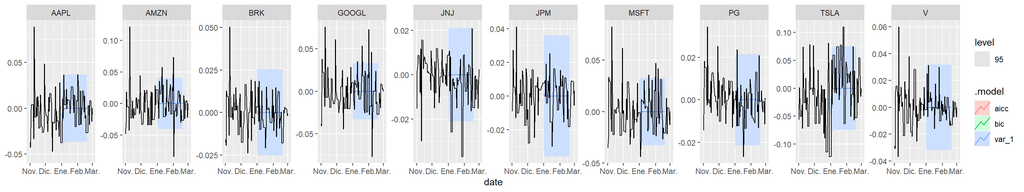

```r
fit%>%
  forecast(h=50) %>%
  autoplot(ts_tsibble3 %>% filter((year(date) >= 2022 & month(date) >= 11) | year(date) >= 2023), level = 95)
```

# 5 Vector Autoregressive for high dimension

For avoiding over fitting, shrinkage models as Lasso or Ridge penalization can be added to the model. We will use Lasso penalty for selecting a VAR model. However, over fitting does not seems to be happening, as flat forecast are made, we can run it still. This code is inspired from the code in [3].

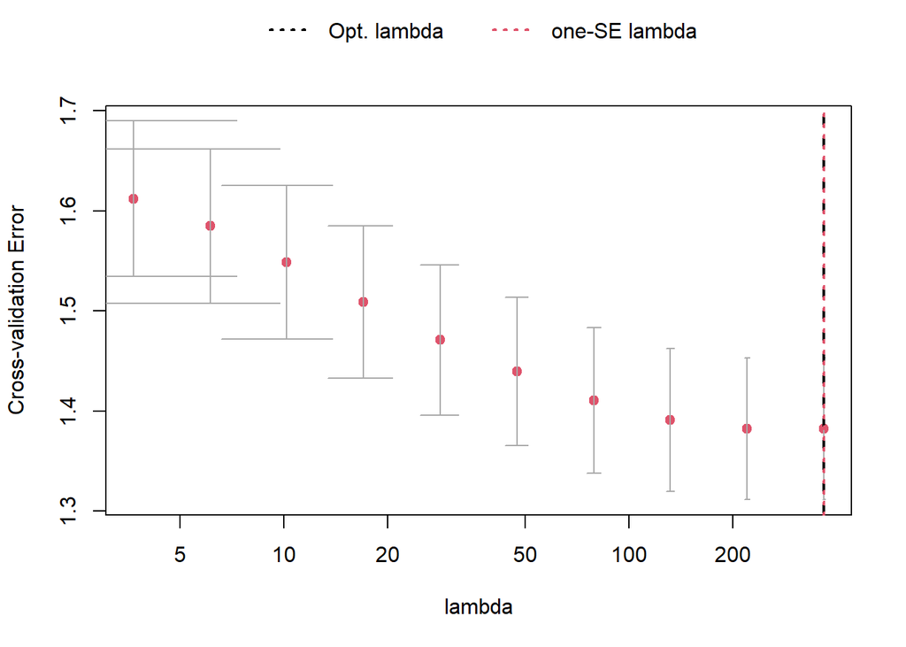

```r
library(bigtime)

VAR.L1 <- bigtime::sparseVAR(Y=scale(as.matrix(head(ts_tsibble3[,-1],-30))), # leave 30 days for testing
                              h = 30, # evaluate forecasts 1 day ahead
                              selection = "cv", # using time series cross-validation
                              VARpen = "L1") # using the lasso penalty)

plot_cv(VAR.L1)
```

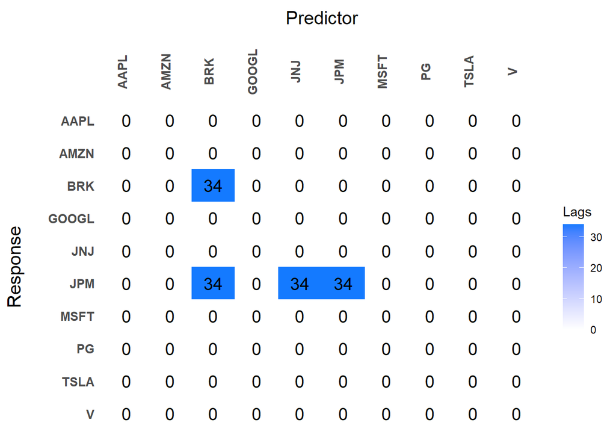

```r
LhatL1 <- lagmatrix(fit=VAR.L1, returnplot=TRUE)
```

```r
recursiveforecast(VAR.L1, h=10)$fcst
```

```
##              AAPL        MSFT       GOOGL            PG        AMZN       TSLA
##  [1,] 0.001447102 0.002847934 0.003583293 -0.0006509187 0.000788505 0.00389257
##  [2,] 0.001447102 0.002847934 0.003583293 -0.0006509187 0.000788505 0.00389257
##  [3,] 0.001447102 0.002847934 0.003583293 -0.0006509187 0.000788505 0.00389257
##  [4,] 0.001447102 0.002847934 0.003583293 -0.0006509187 0.000788505 0.00389257
##  [5,] 0.001447102 0.002847934 0.003583293 -0.0006509187 0.000788505 0.00389257
##  [6,] 0.001447102 0.002847934 0.003583293 -0.0006509187 0.000788505 0.00389257
##  [7,] 0.001447102 0.002847934 0.003583293 -0.0006509187 0.000788505 0.00389257
##  [8,] 0.001447102 0.002847934 0.003583293 -0.0006509187 0.000788505 0.00389257
##  [9,] 0.001447102 0.002847934 0.003583293 -0.0006509187 0.000788505 0.00389257
## [10,] 0.001447102 0.002847934 0.003583293 -0.0006509187 0.000788505 0.00389257
##                 BRK          JNJ          JPM          V
##  [1,] -1.108157e-03 -0.001222623 -0.020986705 -0.0011714
##  [2,]  2.309547e-05 -0.001222623  0.002143037 -0.0011714
##  [3,] -2.015489e-04 -0.001222623 -0.005839735 -0.0011714
##  [4,] -2.015489e-04 -0.001222623 -0.005839735 -0.0011714
##  [5,] -2.015489e-04 -0.001222623 -0.005839735 -0.0011714
##  [6,] -2.015489e-04 -0.001222623 -0.005839735 -0.0011714
##  [7,] -8.956681e-04 -0.001222623 -0.020147419 -0.0011714
##  [8,]  3.035262e-04 -0.001222623  0.011234031 -0.0011714
##  [9,] -1.105179e-03 -0.001222623 -0.028162909 -0.0011714
## [10,]  5.805235e-04 -0.001222623  0.022725612 -0.0011714
```

```r
# real values for last 50 days
tail(ts_tsibble3,10)
```

```
## # A tsibble: 10 x 11 [1D]
##    date            AAPL      MSFT     GOOGL        PG     AMZN     TSLA      BRK
##    <date>         <dbl>     <dbl>     <dbl>     <dbl>    <dbl>    <dbl>    <dbl>
##  1 2023-02-20 -0.0267   -0.0209   -0.0271   -0.000714 -2.70e-2 -5.25e-2 -1.79e-2
##  2 2023-02-21  0.00290  -0.00459  -0.00153   0.00422   1.28e-2  1.77e-2  1.45e-3
##  3 2023-02-22  0.00329   0.0130   -0.00829  -0.00320   3.13e-4  6.02e-3 -2.97e-4
##  4 2023-02-23 -0.0180   -0.0218   -0.0194   -0.00564  -2.42e-2 -2.57e-2  3.13e-3
##  5 2023-02-24  0.00825   0.00377   0.00830  -0.000862  2.78e-3  5.46e-2  2.11e-3
##  6 2023-02-25  0.00825   0.00377   0.00830  -0.000862  2.78e-3  5.46e-2  2.11e-3
##  7 2023-02-26  0.00825   0.00377   0.00830  -0.000862  2.78e-3  5.46e-2  2.11e-3
##  8 2023-02-27 -0.00345  -0.00296   0.00211  -0.0114    5.01e-3 -9.25e-3  1.71e-3
##  9 2023-02-28 -0.0142   -0.0126    0.00333   0.000727 -2.19e-2 -1.43e-2 -1.83e-3
## 10 2023-03-01  0.000360  0.000340 -0.000618  0.000908  4.29e-4  1.63e-5 -7.88e-4
## # … with 3 more variables: JNJ <dbl>, JPM <dbl>, V <dbl>
```

# 6 Machine Learning applied to time series

After performing the VAR methods, we can compute many of the machine learning techniques applied to time series. For doing this, we will: generate a train/test split, compute the methods, generate a “cross validation” with mooving training window, compute the methods and obtain forecast with the confidence intervals for those models. The code applied in this section is inspired by the code from [3] and [4].

First, load some libraries:

```r
library(tidyverse) # great collection of packages to visualize and manage datasets
library(lubridate) # to work with dates
library(fpp3)
library(tsibble) # tidy data structure for time series
library(tidymodels) # machine learning ecosystem of packages (the new caret)
library(modeltime) # automatic forecasting using machine learning
library(modeltime.ensemble) # ensembles
library(timetk) # similar to tidyverse but for time series (visualization and management of times series)
library(recipes)
library(utils)
library(randomForest)
```

## 6.1 Train-Test split

The objective of this project is to find a suitable model to forecast stock prices in a 30 days horizon. To do this, we can set many train and test sets, with a sliding window, to compute the model and then get the average performance for that model.

```r
ts_tsibble3$date <- as.Date(ts_tsibble3$date)

lag_roll_transformer_grouped <- function(data){
    data %>%
        group_by(Category) %>%
        tk_augment_differences(Change, .lags = 1, .differences=1) %>%
        ungroup()
                                              }
ts.tidy <- pivot_longer(ts_tsibble3,c(2:11),
                        names_to = "Category",
                        values_to = "Change")


# Lags include NAs that we need to remove
ts.tidy.feature <- ts.tidy %>%
                  lag_roll_transformer_grouped() %>%
                  drop_na()
```

The forecasting horizon will be the same as the previous section *30 days*. Also, the window in which the model will be trained will be *180 days*. Those periods are considered to be a good estimation, as stocks trends may change in a few months. Five slices of the cross validation for the *Change* variable can be see below:

```r
splits_multi <- ts.tidy.feature %>%
                time_series_cv(date_var = date,
                                       initial     = "180 days", # window for train set
                                       assess      = "30 days",
                                       skip        = "30 days",
                                       slice_limit = 5, # maximum number of blocks/slices
                                       cumulative  = FALSE)
```

```
## Data is not ordered by the 'date_var'. Resamples will be arranged by `date`.
```

```
## Overlapping Timestamps Detected. Processing overlapping time series together using sliding windows.
```

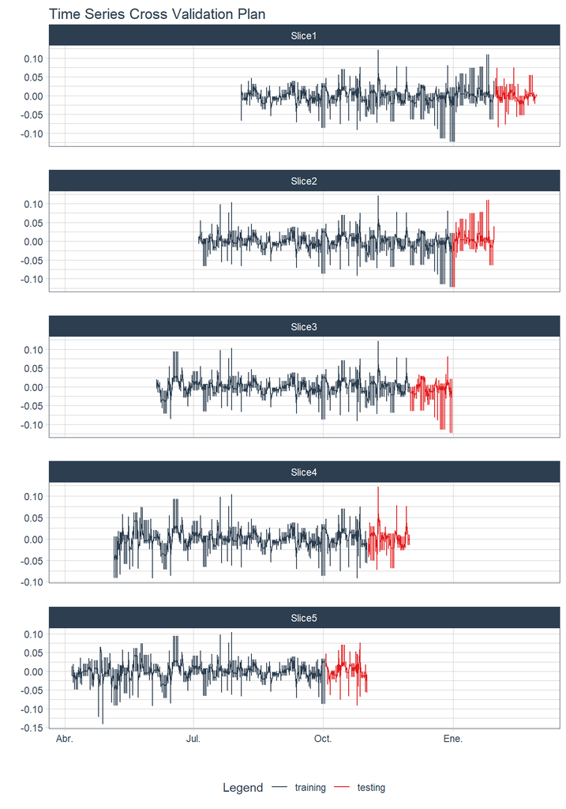

```r
# visualize the splits
splits_multi %>%
  tk_time_series_cv_plan() %>%
  plot_time_series_cv_plan(date,Change, .interactive = FALSE)
```

## 6.2 Recipe object

For training a Machine Learning model for time series forecasting in R, we should generate a recipe object which transforms the data set into a *recipe* object. This is a data frame-like object which has every instance and all the features involved. Two differenct recipes have been computed, in one of those, dates have been removed.

```r
# Recipe without dates:

rec_obj <- recipe(Change ~ ., training(splits_multi$splits[[1]])) %>%
  step_timeseries_signature(date) %>%
  step_rm(date,date_index.num, date_half, date_quarter, date_month) %>%
  step_rm(contains("am.pm"), contains("hour"), contains("minute"),contains("day"),
  contains("second"), contains("xts"), contains("iso"), contains("month"),
  contains("year"), contains("week")) %>%
  step_dummy(all_nominal_predictors(), one_hot = TRUE) %>%
  step_zv(all_predictors()) %>% # remove variables with 0 variance
  step_normalize(all_numeric_predictors())


# Recipe with dates (for NN and Adv.Prophet):

rec_obj_date <- recipe(Change ~ ., training(splits_multi$splits[[1]])) %>%
  step_timeseries_signature(date) %>%
  step_rm(date_index.num, date_half, date_quarter, date_month) %>%
  step_rm(contains("am.pm"), contains("hour"), contains("minute"),contains("day"),
  contains("second"), contains("xts"), contains("iso"), contains("month"),
  contains("year"), contains("week")) %>%
  step_dummy(all_nominal_predictors(), one_hot = TRUE) %>%
  step_zv(all_predictors()) %>% # remove variables with 0 variance
  step_normalize(all_numeric_predictors())
```

## 6.3 Training Models for one slice

We can train many machine learning models for the last slice of the windows plotted in *Section 6.1*. In this case, the first slice will be the one that computes the metrics for the model, and the traning set can be seen in the corresponding plot.

We will train the following models:

- Linear regression
- Random forest
- XG Boost
- Neural network for time series forecast (NNETAR)
- Prophet regression

For comparing with simpler methods, ARIMA, ETS and Prophet will be also calculated.

```r
# Setting the hold-out
sp <- 1

# ARIMA
model_fit_arima =
  arima_reg() %>%
  set_engine("auto_arima") %>%
  fit(Change ~ date, training(splits_multi$splits[[sp]]))
```

```
## frequency = 7 observations per 1 week
```

```r
# Error-Trend-Season (ETS) model
model_fit_ets =
  exp_smoothing() %>%
  set_engine("ets") %>%
  fit(Change ~ date, training(splits_multi$splits[[sp]]))
```

```
## frequency = 7 observations per 1 week
```

```r
# Now the prophet by facebook
model_fit_prophet <- prophet_reg() %>%
  set_engine("prophet", monthly.seasonality = TRUE) %>%
  fit(Change ~ date, training(splits_multi$splits[[sp]]))
```

```
## Disabling yearly seasonality. Run prophet with yearly.seasonality=TRUE to override this.
```

```
## Disabling daily seasonality. Run prophet with daily.seasonality=TRUE to override this.
```

```r
# glmnet
model_spec_glmnet <- linear_reg(penalty = 0.01, mixture = 0.5) %>%
                      set_engine("glmnet")

workflow_fit_glmnet <- workflow() %>%
                        add_model(model_spec_glmnet) %>%
                        add_recipe(rec_obj) %>%
                        fit(training(splits_multi$splits[[sp]]))

# randomForest
model_spec_rf <- rand_forest(trees = 100, mode = "regression") %>%
                  set_engine("randomForest")

workflow_fit_rf <- workflow() %>%
                  add_model(model_spec_rf) %>%
                  add_recipe(rec_obj) %>%
                  fit(training(splits_multi$splits[[sp]]))

# XGBoost
model_spec_xgboost <- boost_tree(mode = "regression") %>%
                      set_engine("xgboost")

wflw_fit_xgboost <- workflow() %>%
                    add_model(model_spec_xgboost) %>%
                    add_recipe(rec_obj) %>%
                    fit(training(splits_multi$splits[[sp]]))

# NNETAR
model_spec_nnetar <- nnetar_reg(mode = "regression") %>%
                    set_engine("nnetar")

wflw_fit_nnetar <- workflow() %>%
                  add_model(model_spec_nnetar) %>%
                  add_recipe(rec_obj_date) %>%
                  fit(data = training(splits_multi$splits[[sp]]))
```

```
## frequency = 7 observations per 1 week
```

```r
# Prophet with all the features

model_spec_prophet <- prophet_reg(seasonality_yearly = FALSE) %>%
                      set_engine("prophet")

wflw_fit_prophet <- workflow() %>%
                    add_model(model_spec_prophet) %>%
                    add_recipe(rec_obj_date) %>%
                    fit(training(splits_multi$splits[[sp]]))
```

```
## Disabling daily seasonality. Run prophet with daily.seasonality=TRUE to override this.
```

```r
model_table <- modeltime_table(
                model_fit_arima,
                model_fit_ets,
                model_fit_prophet,
                workflow_fit_glmnet,
                workflow_fit_rf,
                wflw_fit_xgboost,
                wflw_fit_nnetar,
                wflw_fit_prophet
                               )
model_table
```

```
## # Modeltime Table
## # A tibble: 8 × 3
##   .model_id .model     .model_desc
##       <int> <list>     <chr>
## 1         1 <fit[+]>   ARIMA(5,0,2)(1,0,2)[7] WITH ZERO MEAN
## 2         2 <fit[+]>   ETS(A,N,N)
## 3         3 <fit[+]>   PROPHET
## 4         4 <workflow> GLMNET
## 5         5 <workflow> RANDOMFOREST
## 6         6 <workflow> XGBOOST
## 7         7 <workflow> NNAR(1,1,10)[7]
## 8         8 <workflow> PROPHET W/ REGRESSORS
```

```r
calibration_table <- model_table %>%
                      modeltime_calibrate(
                                          new_data = testing(splits_multi$splits[[sp]]),
                                          id = "Category"
                                          )
calibration_table
```

```
## # Modeltime Table
## # A tibble: 8 × 5
##   .model_id .model     .model_desc                           .type .calibratio…¹
##       <int> <list>     <chr>                                 <chr> <list>
## 1         1 <fit[+]>   ARIMA(5,0,2)(1,0,2)[7] WITH ZERO MEAN Test  <tibble>
## 2         2 <fit[+]>   ETS(A,N,N)                            Test  <tibble>
## 3         3 <fit[+]>   PROPHET                               Test  <tibble>
## 4         4 <workflow> GLMNET                                Test  <tibble>
## 5         5 <workflow> RANDOMFOREST                          Test  <tibble>
## 6         6 <workflow> XGBOOST                               Test  <tibble>
## 7         7 <workflow> NNAR(1,1,10)[7]                       Test  <tibble>
## 8         8 <workflow> PROPHET W/ REGRESSORS                 Test  <tibble>
## # … with abbreviated variable name ¹.calibration_data
```

After computing all the models, we can calculate the metrics comparing the forecasted values with the test set.

```r
calibration_table %>%
    modeltime_accuracy(acc_by_id = TRUE) %>%
    table_modeltime_accuracy(.interactive = FALSE)
```

Accuracy Table

| .model_id | .model_desc | .type | Category | mae | mape | mase | smape | rmse | rsq |
| --- | --- | --- | --- | --- | --- | --- | --- | --- | --- |
| 1 | ARIMA(5,0,2)(1,0,2)[7] WITH ZERO MEAN | Test | AAPL | 0.01 | 99.82 | 1.05 | 198.68 | 0.02 | 0.20 |
| 1 | ARIMA(5,0,2)(1,0,2)[7] WITH ZERO MEAN | Test | AMZN | 0.02 | 99.34 | 0.85 | 197.70 | 0.03 | 0.03 |
| 1 | ARIMA(5,0,2)(1,0,2)[7] WITH ZERO MEAN | Test | BRK | 0.01 | 100.82 | 1.07 | 196.78 | 0.01 | 0.01 |
| 1 | ARIMA(5,0,2)(1,0,2)[7] WITH ZERO MEAN | Test | GOOGL | 0.02 | 100.15 | 0.92 | 199.63 | 0.03 | 0.16 |
| 1 | ARIMA(5,0,2)(1,0,2)[7] WITH ZERO MEAN | Test | JNJ | 0.01 | 98.25 | 0.96 | 194.19 | 0.01 | 0.09 |
| 1 | ARIMA(5,0,2)(1,0,2)[7] WITH ZERO MEAN | Test | JPM | 0.01 | 102.04 | 1.32 | 199.64 | 0.01 | 0.00 |
| 1 | ARIMA(5,0,2)(1,0,2)[7] WITH ZERO MEAN | Test | MSFT | 0.02 | 100.15 | 0.99 | 199.47 | 0.02 | 0.07 |
| 1 | ARIMA(5,0,2)(1,0,2)[7] WITH ZERO MEAN | Test | PG | 0.01 | 101.73 | 0.99 | 198.56 | 0.01 | 0.02 |
| 1 | ARIMA(5,0,2)(1,0,2)[7] WITH ZERO MEAN | Test | TSLA | 0.03 | 99.55 | 1.05 | 198.27 | 0.04 | 0.06 |
| 1 | ARIMA(5,0,2)(1,0,2)[7] WITH ZERO MEAN | Test | V | 0.01 | 98.09 | 1.08 | 193.89 | 0.01 | 0.02 |
| 2 | ETS(A,N,N) | Test | AAPL | 0.02 | 225.44 | 1.25 | 135.92 | 0.02 | NA |
| 2 | ETS(A,N,N) | Test | AMZN | 0.02 | 366.92 | 1.06 | 153.27 | 0.03 | NA |
| 2 | ETS(A,N,N) | Test | BRK | 0.01 | 921.59 | 1.94 | 152.61 | 0.01 | NA |
| 2 | ETS(A,N,N) | Test | GOOGL | 0.02 | 460.53 | 1.17 | 160.60 | 0.03 | NA |
| 2 | ETS(A,N,N) | Test | JNJ | 0.01 | 492.13 | 1.93 | 166.13 | 0.02 | NA |
| 2 | ETS(A,N,N) | Test | JPM | 0.01 | 124.14 | 1.42 | 99.38 | 0.01 | NA |
| 2 | ETS(A,N,N) | Test | MSFT | 0.02 | 277.34 | 1.26 | 160.57 | 0.02 | NA |
| 2 | ETS(A,N,N) | Test | PG | 0.01 | 531.85 | 1.85 | 158.16 | 0.01 | NA |
| 2 | ETS(A,N,N) | Test | TSLA | 0.03 | 2135.39 | 1.02 | 138.51 | 0.04 | NA |
| 2 | ETS(A,N,N) | Test | V | 0.01 | 645.92 | 2.24 | 153.51 | 0.01 | NA |
| 3 | PROPHET | Test | AAPL | 0.01 | 113.13 | 1.07 | 169.84 | 0.02 | 0.00 |
| 3 | PROPHET | Test | AMZN | 0.02 | 131.34 | 0.88 | 175.37 | 0.03 | 0.02 |
| 3 | PROPHET | Test | BRK | 0.01 | 177.84 | 1.12 | 159.38 | 0.01 | 0.00 |
| 3 | PROPHET | Test | GOOGL | 0.02 | 109.48 | 0.94 | 160.76 | 0.03 | 0.00 |
| 3 | PROPHET | Test | JNJ | 0.01 | 131.05 | 1.05 | 169.03 | 0.01 | 0.04 |
| 3 | PROPHET | Test | JPM | 0.01 | 93.38 | 1.28 | 162.09 | 0.01 | 0.00 |
| 3 | PROPHET | Test | MSFT | 0.02 | 128.93 | 1.02 | 184.74 | 0.02 | 0.11 |
| 3 | PROPHET | Test | PG | 0.01 | 136.67 | 1.04 | 175.47 | 0.01 | 0.02 |
| 3 | PROPHET | Test | TSLA | 0.03 | 647.91 | 1.05 | 186.40 | 0.04 | 0.01 |
| 3 | PROPHET | Test | V | 0.01 | 210.25 | 1.20 | 172.18 | 0.01 | 0.07 |
| 4 | GLMNET | Test | AAPL | 0.01 | 100.87 | 0.89 | 134.18 | 0.02 | 0.29 |
| 4 | GLMNET | Test | AMZN | 0.02 | 193.81 | 0.75 | 157.65 | 0.02 | 0.51 |
| 4 | GLMNET | Test | BRK | 0.01 | 139.51 | 0.93 | 136.45 | 0.01 | 0.29 |
| 4 | GLMNET | Test | GOOGL | 0.02 | 135.97 | 0.77 | 152.45 | 0.02 | 0.46 |
| 4 | GLMNET | Test | JNJ | 0.01 | 103.48 | 0.81 | 135.39 | 0.01 | 0.41 |
| 4 | GLMNET | Test | JPM | 0.01 | 86.97 | 1.17 | 142.69 | 0.01 | 0.24 |
| 4 | GLMNET | Test | MSFT | 0.01 | 120.95 | 0.87 | 143.57 | 0.02 | 0.32 |
| 4 | GLMNET | Test | PG | 0.01 | 103.80 | 0.79 | 114.54 | 0.01 | 0.38 |
| 4 | GLMNET | Test | TSLA | 0.03 | 608.37 | 0.92 | 153.57 | 0.03 | 0.34 |
| 4 | GLMNET | Test | V | 0.00 | 104.46 | 0.89 | 123.73 | 0.01 | 0.26 |
| 5 | RANDOMFOREST | Test | AAPL | 0.01 | 110.34 | 0.84 | 128.57 | 0.01 | 0.32 |
| 5 | RANDOMFOREST | Test | AMZN | 0.02 | 317.96 | 0.75 | 130.87 | 0.02 | 0.41 |
| 5 | RANDOMFOREST | Test | BRK | 0.01 | 152.20 | 0.96 | 145.35 | 0.01 | 0.22 |
| 5 | RANDOMFOREST | Test | GOOGL | 0.02 | 244.78 | 0.80 | 144.30 | 0.02 | 0.36 |
| 5 | RANDOMFOREST | Test | JNJ | 0.01 | 103.22 | 0.80 | 143.42 | 0.01 | 0.42 |
| 5 | RANDOMFOREST | Test | JPM | 0.01 | 86.67 | 1.13 | 149.93 | 0.01 | 0.21 |
| 5 | RANDOMFOREST | Test | MSFT | 0.01 | 110.03 | 0.85 | 131.95 | 0.02 | 0.37 |
| 5 | RANDOMFOREST | Test | PG | 0.01 | 135.97 | 0.84 | 156.16 | 0.01 | 0.31 |
| 5 | RANDOMFOREST | Test | TSLA | 0.03 | 779.58 | 0.94 | 130.05 | 0.03 | 0.29 |
| 5 | RANDOMFOREST | Test | V | 0.01 | 108.70 | 0.93 | 137.34 | 0.01 | 0.22 |
| 6 | XGBOOST | Test | AAPL | 0.01 | 145.62 | 0.88 | 119.55 | 0.01 | 0.28 |
| 6 | XGBOOST | Test | AMZN | 0.02 | 324.96 | 0.74 | 143.36 | 0.02 | 0.46 |
| 6 | XGBOOST | Test | BRK | 0.01 | 252.75 | 0.95 | 128.92 | 0.01 | 0.24 |
| 6 | XGBOOST | Test | GOOGL | 0.02 | 153.90 | 0.81 | 127.72 | 0.02 | 0.36 |
| 6 | XGBOOST | Test | JNJ | 0.01 | 176.84 | 0.90 | 140.47 | 0.01 | 0.48 |
| 6 | XGBOOST | Test | JPM | 0.01 | 82.80 | 1.05 | 115.71 | 0.01 | 0.24 |
| 6 | XGBOOST | Test | MSFT | 0.01 | 185.90 | 0.89 | 143.09 | 0.02 | 0.33 |
| 6 | XGBOOST | Test | PG | 0.01 | 254.01 | 0.98 | 146.12 | 0.01 | 0.35 |
| 6 | XGBOOST | Test | TSLA | 0.03 | 696.47 | 0.88 | 129.69 | 0.03 | 0.35 |
| 6 | XGBOOST | Test | V | 0.01 | 197.83 | 0.94 | 121.17 | 0.01 | 0.22 |
| 7 | NNAR(1,1,10)[7] | Test | AAPL | 0.01 | 127.11 | 0.79 | 96.48 | 0.01 | 0.38 |
| 7 | NNAR(1,1,10)[7] | Test | AMZN | 0.02 | 294.67 | 0.71 | 126.92 | 0.02 | 0.39 |
| 7 | NNAR(1,1,10)[7] | Test | BRK | 0.01 | 401.83 | 0.80 | 99.17 | 0.01 | 0.43 |
| 7 | NNAR(1,1,10)[7] | Test | GOOGL | 0.02 | 526.86 | 0.78 | 128.51 | 0.02 | 0.48 |
| 7 | NNAR(1,1,10)[7] | Test | JNJ | 0.01 | 180.23 | 0.84 | 133.16 | 0.01 | 0.37 |
| 7 | NNAR(1,1,10)[7] | Test | JPM | 0.01 | 120.48 | 1.34 | 126.80 | 0.01 | 0.13 |
| 7 | NNAR(1,1,10)[7] | Test | MSFT | 0.01 | 185.50 | 0.75 | 102.92 | 0.01 | 0.49 |
| 7 | NNAR(1,1,10)[7] | Test | PG | 0.01 | 206.14 | 0.79 | 111.37 | 0.01 | 0.45 |
| 7 | NNAR(1,1,10)[7] | Test | TSLA | 0.03 | 1987.02 | 0.89 | 128.15 | 0.03 | 0.31 |
| 7 | NNAR(1,1,10)[7] | Test | V | 0.01 | 280.57 | 1.21 | 125.82 | 0.01 | 0.24 |
| 8 | PROPHET W/ REGRESSORS | Test | AAPL | 0.01 | 217.11 | 0.90 | 117.16 | 0.02 | 0.27 |
| 8 | PROPHET W/ REGRESSORS | Test | AMZN | 0.02 | 297.02 | 0.73 | 133.59 | 0.02 | 0.49 |
| 8 | PROPHET W/ REGRESSORS | Test | BRK | 0.01 | 561.84 | 1.25 | 131.94 | 0.01 | 0.25 |
| 8 | PROPHET W/ REGRESSORS | Test | GOOGL | 0.02 | 210.23 | 0.79 | 137.50 | 0.02 | 0.45 |
| 8 | PROPHET W/ REGRESSORS | Test | JNJ | 0.01 | 310.64 | 1.15 | 144.34 | 0.01 | 0.38 |
| 8 | PROPHET W/ REGRESSORS | Test | JPM | 0.01 | 98.37 | 1.11 | 101.26 | 0.01 | 0.20 |
| 8 | PROPHET W/ REGRESSORS | Test | MSFT | 0.01 | 268.16 | 0.95 | 143.71 | 0.02 | 0.27 |
| 8 | PROPHET W/ REGRESSORS | Test | PG | 0.01 | 343.67 | 1.21 | 152.63 | 0.01 | 0.36 |
| 8 | PROPHET W/ REGRESSORS | Test | TSLA | 0.03 | 1494.03 | 0.89 | 138.05 | 0.03 | 0.33 |
| 8 | PROPHET W/ REGRESSORS | Test | V | 0.01 | 577.26 | 1.43 | 142.76 | 0.01 | 0.17 |

We can also plot the forecasted values and the confidence interval for every model and every stock price.

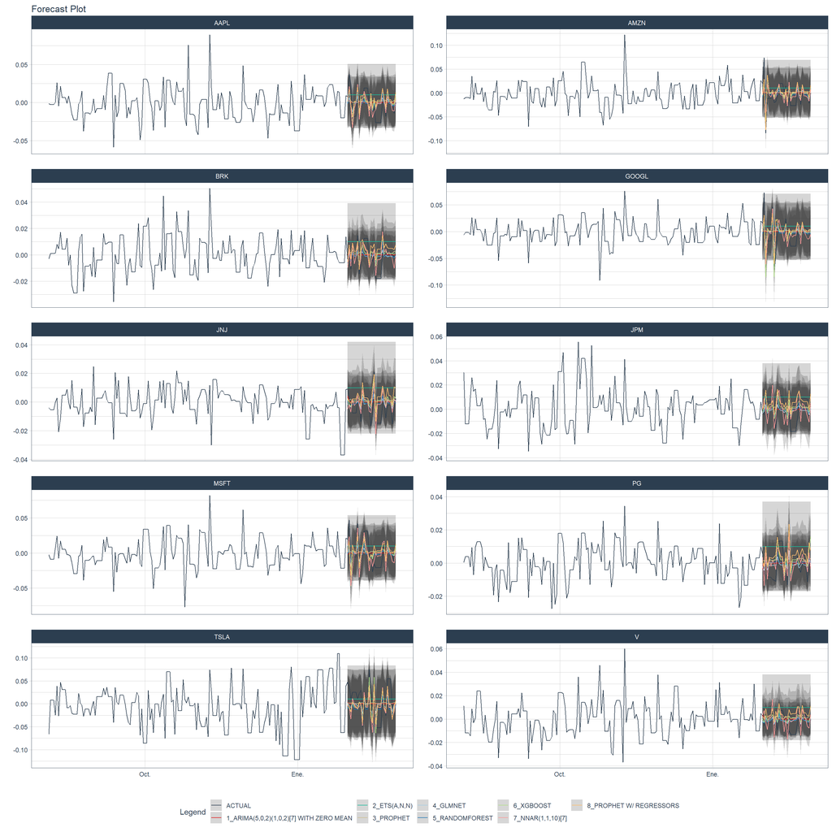

```r
calibration_table %>%
    modeltime_forecast(
        new_data    = testing(splits_multi$splits[[sp]]),
        actual_data = bind_rows(training(splits_multi$splits[[sp]]),
                                testing(splits_multi$splits[[sp]])),
        conf_by_id  = TRUE
    ) %>%
    group_by(Category) %>%
    plot_modeltime_forecast(
        .facet_ncol  = 2,
        .interactive = FALSE
    )
```

## 6.4 Retrain models for accuracy resample

Now, we will train the models considering all the five sliding windows shown before. For doing this, we will use the function **modeltime_fit_resamples**.

```r
resample_results <- model_table %>%
  modeltime_fit_resamples(
    resamples = splits_multi,
    control   = control_resamples(verbose = FALSE)
  )
```

```r
resample_results
```

```
## # Modeltime Table
## # A tibble: 8 × 4
##   .model_id .model     .model_desc                           .resample_results
##       <int> <list>     <chr>                                 <list>
## 1         1 <fit[+]>   ARIMA(5,0,2)(1,0,2)[7] WITH ZERO MEAN <rsmp[+]>
## 2         2 <fit[+]>   ETS(A,N,N)                            <rsmp[+]>
## 3         3 <fit[+]>   PROPHET                               <rsmp[+]>
## 4         4 <workflow> GLMNET                                <rsmp[+]>
## 5         5 <workflow> RANDOMFOREST                          <rsmp[+]>
## 6         6 <workflow> XGBOOST                               <rsmp[+]>
## 7         7 <workflow> NNAR(1,1,10)[7]                       <rsmp[+]>
## 8         8 <workflow> PROPHET W/ REGRESSORS                 <rsmp[+]>
```

```r
resample_results %>%
  modeltime_resample_accuracy(summary_fns = list(mean = mean)) %>%
  table_modeltime_accuracy(.interactive = FALSE)
```

Accuracy Table

| .model_id | .model_desc | .type | n | mae_mean | mape_mean | mase_mean | smape_mean | rmse_mean | rsq_mean |
| --- | --- | --- | --- | --- | --- | --- | --- | --- | --- |
| 1 | ARIMA(5,0,2)(1,0,2)[7] WITH ZERO MEAN | Resamples | 5 | 0.02 | Inf | 0.87 | 197.34 | 0.02 | 0.01 |
| 2 | ETS(A,N,N) | Resamples | 5 | 0.02 | Inf | 1.11 | 148.60 | 0.03 | NA |
| 3 | PROPHET | Resamples | 5 | 0.02 | Inf | 0.90 | 166.68 | 0.02 | 0.01 |
| 4 | GLMNET | Resamples | 5 | 0.01 | Inf | 0.76 | 141.96 | 0.02 | 0.34 |
| 5 | RANDOMFOREST | Resamples | 5 | 0.01 | Inf | 0.76 | 139.44 | 0.02 | 0.28 |
| 6 | XGBOOST | Resamples | 5 | 0.01 | Inf | 0.74 | 128.62 | 0.02 | 0.31 |
| 7 | NNAR(1,1,10)[7] | Resamples | 5 | 0.01 | Inf | 0.72 | 119.34 | 0.02 | 0.36 |
| 8 | PROPHET W/ REGRESSORS | Resamples | 5 | 0.01 | Inf | 0.78 | 128.63 | 0.02 | 0.32 |

Afer the cross validation train, we can say that the best model is the Neural Network, with a **MASE** of **0.72**. Not a remarkable result though.

## 6.5 Training window optimization

After computing all the methods, the models are not performing as expected, so we can try many different training windows and see if the models improve.

We will set training windows of: 30, 180, 720 and 1440 days.

```r
training_vec <- c(30,180,720,1440)

calib_list <- list()

for (i in 1:length(training_vec)){

  splits_multi <- ts.tidy.feature %>%
                time_series_cv(date_var = date,
                               initial     = paste0(training_vec[i],' days'),
                               assess      = "30 days",
                               skip        = "30 days",
                               slice_limit = 5,
                               cumulative  = FALSE,
                               )

  ################################
  rec_obj <- recipe(Change ~ ., training(splits_multi$splits[[1]]),verbose(data_out = FALSE,data_in = FALSE,ssl=FALSE)) %>%
              step_timeseries_signature(date) %>%
              step_rm(date,date_index.num, date_half, date_quarter, date_month) %>%
              step_rm(contains("am.pm"), contains("hour"), contains("minute"),contains("day"),
              contains("second"), contains("xts"), contains("iso"), contains("month"),
              contains("year"), contains("week")) %>%
              step_dummy(all_nominal_predictors(), one_hot = TRUE) %>%
              step_zv(all_predictors()) %>% # remove variables with 0 variance
              step_normalize(all_numeric_predictors())

  ################################
  # Models
  sp <- 1

  model_spec_glmnet <- linear_reg(penalty = 0.01, mixture = 0.5) %>%
                        set_engine("glmnet")
  workflow_fit_glmnet <- workflow() %>%
                          add_model(model_spec_glmnet) %>%
                          add_recipe(rec_obj) %>%
                          fit(training(splits_multi$splits[[sp]])
                          )

  model_spec_rf <- rand_forest(trees = 100, mode = "regression") %>%
                    set_engine("randomForest")
  workflow_fit_rf <- workflow() %>%
                    add_model(model_spec_rf) %>%
                    add_recipe(rec_obj) %>%
                    fit(training(splits_multi$splits[[sp]])
                    )

  model_spec_xgboost <- boost_tree(mode = "regression") %>%
                        set_engine("xgboost")
  wflw_fit_xgboost <- workflow() %>%
                      add_model(model_spec_xgboost) %>%
                      add_recipe(rec_obj) %>%
                      fit(training(splits_multi$splits[[sp]])
                      )

  ###########################
  model_table <- modeltime_table(
                workflow_fit_glmnet,
                workflow_fit_rf,
                wflw_fit_xgboost
                               )

  calibration_table <- model_table %>%
                      modeltime_calibrate(
                                          new_data = testing(splits_multi$splits[[sp]]),
                                          id = "Category"
                                          )

  ############################
  calib_list[i] <- calibration_table %>%
                    modeltime_accuracy(acc_by_id = TRUE) %>%
                    table_modeltime_accuracy(.interactive = FALSE)


}
```

```r
for (i in 1:length(training_vec)){

  print(calib_list[i])
}
```

```
## [[1]]
## # A tibble: 30 × 10
##    .model_id .model_desc .type Category   mae   mape  mase smape  rmse   rsq
##        <int> <chr>       <chr> <chr>    <dbl>  <dbl> <dbl> <dbl> <dbl> <dbl>
##  1         1 GLMNET      Test  AAPL      0.01  132.   0.93  132.  0.02  0.29
##  2         1 GLMNET      Test  AMZN      0.02  184.   0.79  147.  0.02  0.51
##  3         1 GLMNET      Test  BRK       0.01  294.   1.03  129.  0.01  0.29
##  4         1 GLMNET      Test  GOOGL     0.02  166.   0.83  145.  0.02  0.46
##  5         1 GLMNET      Test  JNJ       0.01  197.   1.04  153.  0.01  0.41
##  6         1 GLMNET      Test  JPM       0.01   82.2  1.12  128.  0.01  0.24
##  7         1 GLMNET      Test  MSFT      0.01  161.   0.93  156.  0.02  0.32
##  8         1 GLMNET      Test  PG        0.01  183.   0.98  155.  0.01  0.38
##  9         1 GLMNET      Test  TSLA      0.03 1615.   0.9   145.  0.03  0.34
## 10         1 GLMNET      Test  V         0.01  253.   1.09  143.  0.01  0.26
## # … with 20 more rows
##
## [[1]]
## # A tibble: 30 × 10
##    .model_id .model_desc .type Category   mae  mape  mase smape  rmse   rsq
##        <int> <chr>       <chr> <chr>    <dbl> <dbl> <dbl> <dbl> <dbl> <dbl>
##  1         1 GLMNET      Test  AAPL      0.01 101.   0.89  134.  0.02  0.29
##  2         1 GLMNET      Test  AMZN      0.02 194.   0.75  158.  0.02  0.51
##  3         1 GLMNET      Test  BRK       0.01 140.   0.93  136.  0.01  0.29
##  4         1 GLMNET      Test  GOOGL     0.02 136.   0.77  152.  0.02  0.46
##  5         1 GLMNET      Test  JNJ       0.01 103.   0.81  135.  0.01  0.41
##  6         1 GLMNET      Test  JPM       0.01  87.0  1.17  143.  0.01  0.24
##  7         1 GLMNET      Test  MSFT      0.01 121.   0.87  144.  0.02  0.32
##  8         1 GLMNET      Test  PG        0.01 104.   0.79  115.  0.01  0.38
##  9         1 GLMNET      Test  TSLA      0.03 608.   0.92  154.  0.03  0.34
## 10         1 GLMNET      Test  V         0    104.   0.89  124.  0.01  0.26
## # … with 20 more rows
##
## [[1]]
## # A tibble: 30 × 10
##    .model_id .model_desc .type Category   mae  mape  mase smape  rmse   rsq
##        <int> <chr>       <chr> <chr>    <dbl> <dbl> <dbl> <dbl> <dbl> <dbl>
##  1         1 GLMNET      Test  AAPL      0.01 107.   0.9   138.  0.02  0.29
##  2         1 GLMNET      Test  AMZN      0.02 187.   0.77  163.  0.02  0.51
##  3         1 GLMNET      Test  BRK       0.01 138.   0.93  150.  0.01  0.29
##  4         1 GLMNET      Test  GOOGL     0.02 111.   0.78  155.  0.02  0.46
```

[output cut: 8 more lines]

```
## [[1]]
## # A tibble: 30 × 10
##    .model_id .model_desc .type Category   mae   mape  mase smape  rmse   rsq
##        <int> <chr>       <chr> <chr>    <dbl>  <dbl> <dbl> <dbl> <dbl> <dbl>
##  1         1 GLMNET      Test  AAPL      0.01  121.   0.9   130.  0.02  0.29
##  2         1 GLMNET      Test  AMZN      0.02  197.   0.77  152.  0.02  0.51
##  3         1 GLMNET      Test  BRK       0.01  210.   0.96  137.  0.01  0.29
##  4         1 GLMNET      Test  GOOGL     0.02  125.   0.78  143.  0.02  0.46
##  5         1 GLMNET      Test  JNJ       0.01  156.   0.93  149.  0.01  0.41
##  6         1 GLMNET      Test  JPM       0.01   81.6  1.12  134.  0.01  0.24
##  7         1 GLMNET      Test  MSFT      0.01  151.   0.9   153.  0.02  0.32
##  8         1 GLMNET      Test  PG        0.01  144.   0.88  148.  0.01  0.38
##  9         1 GLMNET      Test  TSLA      0.03 1063.   0.91  154.  0.03  0.34
## 10         1 GLMNET      Test  V         0.01  200.   0.99  143.  0.01  0.26
## # … with 20 more rows
```

We can see that the metrics are rather constant when varying the training window, so that hyperparameter we can say is not relevant for this data set.

## 6.6 Recursive XGBoost

One last model that we can try for optimizing the forecasting, is the recursive XGBoost. First, we will train a model with the standard hyper parameters, and later we will tune them.

Generate the model for recursive XGBoost:

```r
wflw_xgb <- workflow() %>%
            add_model(
                boost_tree(mode = "regression") %>% set_engine("xgboost")
            ) %>%
            add_recipe(rec_obj) %>%
            fit(training(splits_multi$splits[[sp]]))

# Set the recursive function:
wflw_xgb <- wflw_xgb %>%
            recursive(
                id         = "Category", # We add an id = "id" to specify the groups
                transform  = lag_roll_transformer_grouped,
                train_tail = panel_tail(training(splits_multi$splits[[sp]]), Category, n=length(splits_multi$splits[[sp]])))
```

After calibrating the model, we can compute the metrics.

```r
calib_tbl <- wflw_xgb %>% modeltime_table %>%
    modeltime_calibrate(
      new_data = testing(splits_multi$splits[[sp]]),
      id       = "Category"
    )

calib_tbl %>%
    modeltime_accuracy(acc_by_id = FALSE) %>%
    table_modeltime_accuracy(.interactive = FALSE)
```

Accuracy Table

| .model_id | .model_desc | .type | mae | mape | mase | smape | rmse | rsq |
| --- | --- | --- | --- | --- | --- | --- | --- | --- |
| 1 | RECURSIVE XGBOOST | Test | 0.13 | 8011.62 | 8.03 | 179.65 | 0.13 | 0.01 |

```r
calib_tbl %>%
    modeltime_accuracy(acc_by_id = TRUE) %>%
    table_modeltime_accuracy(.interactive = FALSE)
```

Accuracy Table

| .model_id | .model_desc | .type | Category | mae | mape | mase | smape | rmse | rsq |
| --- | --- | --- | --- | --- | --- | --- | --- | --- | --- |
| 1 | RECURSIVE XGBOOST | Test | AAPL | 0.12 | 2484.36 | 8.72 | 173.52 | 0.12 | 0.01 |
| 1 | RECURSIVE XGBOOST | Test | AMZN | 0.13 | 4737.20 | 6.08 | 170.64 | 0.13 | 0.03 |
| 1 | RECURSIVE XGBOOST | Test | BRK | 0.13 | 12580.14 | 21.11 | 189.48 | 0.14 | 0.00 |
| 1 | RECURSIVE XGBOOST | Test | GOOGL | 0.11 | 5327.48 | 5.61 | 168.54 | 0.12 | 0.02 |
| 1 | RECURSIVE XGBOOST | Test | JNJ | 0.10 | 4702.41 | 12.94 | 179.43 | 0.10 | 0.08 |
| 1 | RECURSIVE XGBOOST | Test | JPM | 0.15 | 2145.90 | 21.64 | 190.14 | 0.16 | 0.00 |
| 1 | RECURSIVE XGBOOST | Test | MSFT | 0.14 | 3286.51 | 8.91 | 180.25 | 0.14 | 0.04 |
| 1 | RECURSIVE XGBOOST | Test | PG | 0.14 | 6805.79 | 20.44 | 188.26 | 0.14 | 0.02 |
| 1 | RECURSIVE XGBOOST | Test | TSLA | 0.14 | 29711.69 | 4.71 | 171.20 | 0.15 | 0.05 |
| 1 | RECURSIVE XGBOOST | Test | V | 0.13 | 8334.68 | 23.17 | 185.06 | 0.13 | 0.02 |

The errors obtained are really high, but we can increase the model performance tuning the hyperparameters. For doing the HP tuning, we can set a grid for looking:

- Learning rate
- Number of tries
- Number of trees

```r
parallel_start(6) # parallel computing with 3 cores

model_tbl <- tibble(expand_grid(
  learn_rate = c(0.3, 0.4, 0.5, 0.6),
  mtry = c(10,20,22),
  trees = c(10,20,100,500)),
) %>%
  create_model_grid(
    f_model_spec = boost_tree,
    engine_name  = "xgboost",
    mode         = "regression"
  )
model_list <- model_tbl$.models

model_wfset <- workflow_set(
  preproc = list(
    rec_obj
  ),
  models = model_list,
  cross = TRUE
)

control_fit_workflowset(
  verbose   = FALSE,
  allow_par = TRUE
)
```

```
## workflowset control object
## --------------------------
## allow_par : TRUE
## cores     : 6
## verbose   : FALSE
## packages  : modeltime parsnip workflows dplyr stats lubridate tidymodels timetk rsample recipes yardstick dials tune xgboost glmnet Matrix prophet rlang Rcpp randomForest modeltime.ensemble modeltime.resample workflowsets modeldata infer scales broom bigtime fable feasts fabletools tsibbledata fp…
```

```r
splits_multi <- ts.tidy.feature %>%
                time_series_cv(date_var = date,
                                       initial     = "180 days", # window for train set
                                       assess      = "30 days",
                                       skip        = "30 days",
                                       slice_limit = 5, # maximum number of blocks/slices
                                       cumulative  = FALSE)
```

```
## Data is not ordered by the 'date_var'. Resamples will be arranged by `date`.
```

```
## Overlapping Timestamps Detected. Processing overlapping time series together using sliding windows.
```

```r
model_parallel_tbl <- model_wfset %>%
  modeltime_fit_workflowset(
    data    = training(splits_multi$splits[[sp]]),
    control = control_fit_workflowset(
      verbose   = FALSE,
      allow_par = TRUE
    )
  )

model_errors = model_parallel_tbl %>%
  modeltime_calibrate(testing(splits_multi$splits[[sp]])) %>%
  modeltime_accuracy()

# Model with the best MAE
which.min(model_errors$mae)
```

```
## [1] 25
```

```r
parallel_stop() # close the parallel clusters
```

```r
model_parallel_tbl %>% filter(.model_id==which.min(model_errors$mae)) %>%
                      modeltime_calibrate(testing(splits_multi$splits[[sp]])) %>%
                      modeltime_accuracy() %>%
                      table_modeltime_accuracy(.interactive = FALSE)
```

Accuracy Table

| .model_id | .model_desc | .type | mae | mape | mase | smape | rmse | rsq |
| --- | --- | --- | --- | --- | --- | --- | --- | --- |
| 25 | RECIPE_BOOST_TREE_25 | Test | 0.01 | 244.86 | 0.71 | 135.62 | 0.02 | 0.31 |

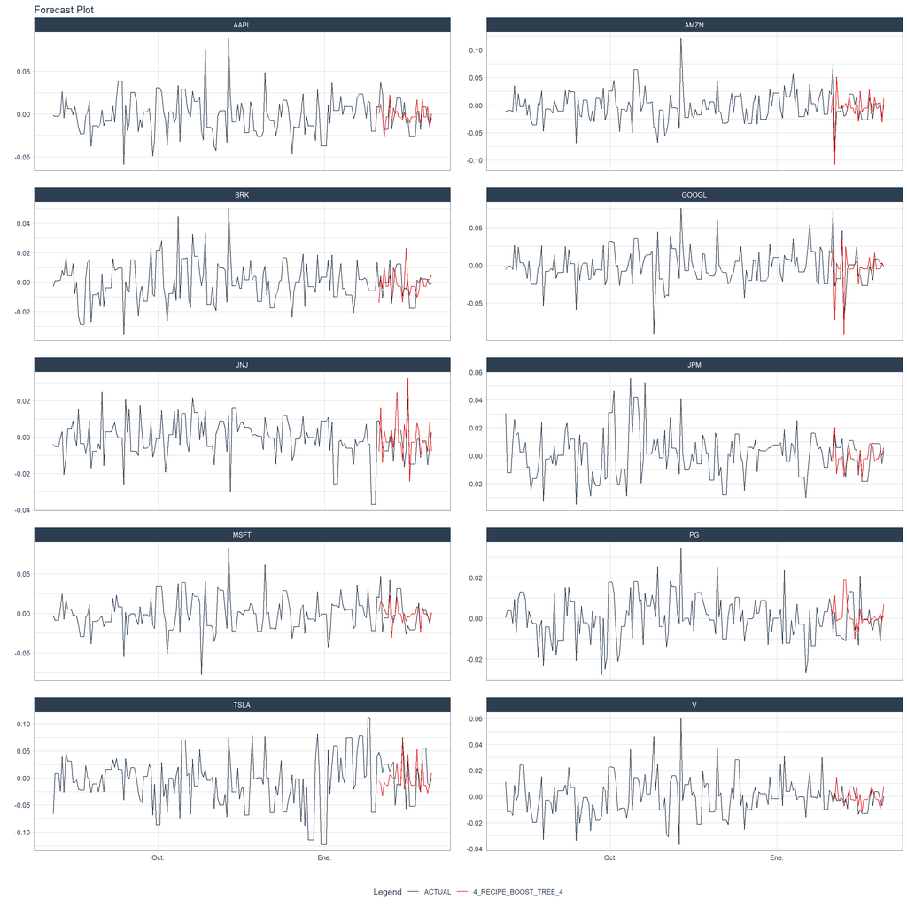

```r
# Type in model_id the best model
model_parallel_tbl %>% filter(.model_id==4) %>%
  modeltime_forecast(
    new_data    = testing(splits_multi$splits[[sp]]),
    actual_data = bind_rows(training(splits_multi$splits[[sp]]), testing(splits_multi$splits[[sp]])),
    keep_data   = TRUE
  ) %>%
  group_by(Category) %>%
  plot_modeltime_forecast(
    .facet_ncol  = 2,
    .interactive = FALSE,
    .conf_interval_show = FALSE
  )
```

# 7 Conclusions

# 8 Sources

[1] *Nasdaq End Of Day (stock prices) https://data.nasdaq.com/databases/EOD/documentation*

[2] *Multivariate Time-Series Models: a case study to analyze macro-economic time series, Javier Nogales UC3M*

[3] *Machine Learning for Time-Series Forecasting, Javier Nogales UC3M*

[4] *Multiple Time-Series Forecasting, Javier Nogales UC3M*